# Assignment 1: Data Screening and EFA

Rushabh Barbhaya

2020-11-30

## Data Screening and EFA Assignment

In this section, import the libraries you will use to complete this assignment.

```r
library(mice)
library(corrplot)
library(rio)
library(psych)
library(GPArotation)
```

## Abstract:

Research in past decades has underscored the importance of body dissatisfaction (BD) in the development and maintenance of disordered eating and health practices (e.g., restrictive eating, exercise habits). Given that 90% of individuals with eating disorders are female, research has focused primarily on female BD. However, male BD has increased sharply over the past decade, and has been linked to maladaptive health behaviors (e.g., steroid use, excessive exercise). Although the presentation of BD contrasts greatly between males and females, many current measures do not delineate between features of male and female BD and are not sensitive to core features of male BD (e.g., muscularity and bulk). Measures specified for males attempt to focus on these core features, but incorrectly assume that these features are equally important for all males. Therefore, this study provided an evaluation of four measures of male BD using item response theory to provide an alternative method of analysis and scoring for a more complete picture of male BD. 841 participants completed the study. By examining the response patterns in the data, the following research questions were answered: 1) What is the level of discriminability of each item and which are the most informative? 2) Are there item biases along the spectrum of BD? 3) Are these scales equivalent measures of BD and are equivalent short-form measures possible? Results also provided evidence for future research on developing a computer-adaptive test (CAT) for BD.

## Data:

Question group 1: Participants rate these questions from 1 (extremely dissatisfied) to 5 (extremely satisfied) about different body parts.

1. Weight
2. Leanness of shoulders
3. Leanness of arms (e.g., biceps/triceps)
4. Muscularity of arms (e.g., biceps/triceps)
5. Leanness of stomach/abdomen
6. Muscularity of stomach/abdomen
7. Leanness of chest/upper torso
8. Muscularity of chest/upper torso
9. Leanness of back
10. Muscularity of back
11. Muscularity of neck
12. Overall body build
13. Overall leanness of body
14. Overall level of body’s muscularity

Question group 2: Participants rate these questions from 1 (never) to 5 (always) about how they feel about their bodies.

15. I think my body should be leaner
16. I am concerned that my stomach is too flabby
17. I feel dissatisfied with my overall body build
18. I think I have too much fat on my body
19. I think my abs are not thin enough
20. Has eating sweets, cakes, or other high calorie food made you feel fat or weak?
21. Have you felt excessively large and rounded (i.e., fat)?
22. Have you felt ashamed of your body size or shape?
23. Has seeing your reflection (e.g., in a mirror or window) made you feel badly about your size or shape?
24. Have you been so worried about your body size or shape that you have been feeling that you ought to diet?
25. I think my body should be leaner
26. I think I have too much fat on my body
27. Eating sweets, cakes, or other high calorie foods makes me feel fat
28. I feel excessively fat
29. Seeing my reflection (e.g., in a mirror or window) makes me feel badly about my body fat

Question group 3: Participants rate these items from 1 (strongly agree) to 5 (strongly disagree) about how they feel about their bodies.

30. I am happy with how much muscle I have compared to how much fat I have
31. Other people think I have a good body
32. I am a good weight for my height
33. I am hesitant to take my shirt off in public because people will look at my body
34. I have thoughts of dissatisfaction towards my body
35. I think I have a generally attractive body
36. My body looks healthy
37. The shape of my body is one of my assets
38. My body is sexually appealing to others

In this section, import the data provided on Canvas.

```r
df = read.csv("assignment1_data.csv")
```

## Data screening:

### Accuracy:

- Check for typos and problems with the dataset - `summary()` or `table()`. Show that the data has scores that are accurate or that are inaccurate.
- Fix any typos in the data by deleting only that point.

```r
# names(df)
summary(df)
```

```
##  Participant_ID        q1              q2              q3
##  Min.   :  1.0   Min.   :1.000   Min.   :1.000   Min.   :1.000
##  1st Qu.:208.2   1st Qu.:2.000   1st Qu.:2.000   1st Qu.:2.000
##  Median :430.0   Median :3.000   Median :3.000   Median :3.000
##  Mean   :422.8   Mean   :2.711   Mean   :3.197   Mean   :2.992
##  3rd Qu.:632.8   3rd Qu.:4.000   3rd Qu.:4.000   3rd Qu.:4.000
##  Max.   :841.0   Max.   :5.000   Max.   :5.000   Max.   :5.000
##                  NA's   :73      NA's   :73      NA's   :73
##        q4              q5              q6              q7
##  Min.   :1.000   Min.   :1.000   Min.   :1.000   Min.   :1.000
##  1st Qu.:2.000   1st Qu.:1.000   1st Qu.:1.000   1st Qu.:2.000
##  Median :3.000   Median :2.000   Median :2.000   Median :3.000
##  Mean   :2.654   Mean   :2.293   Mean   :2.213   Mean   :2.704
##  3rd Qu.:4.000   3rd Qu.:3.000   3rd Qu.:3.000   3rd Qu.:4.000
##  Max.   :5.000   Max.   :5.000   Max.   :5.000   Max.   :5.000
##  NA's   :73      NA's   :73      NA's   :73      NA's   :73
##        q8              q9             q10             q11
##  Min.   :1.000   Min.   :1.000   Min.   :1.000   Min.   :1.000
##  1st Qu.:1.000   1st Qu.:2.000   1st Qu.:2.000   1st Qu.:2.000
##  Median :2.000   Median :3.000   Median :3.000   Median :3.000
##  Mean   :2.549   Mean   :2.938   Mean   :2.752   Mean   :2.929
##  3rd Qu.:4.000   3rd Qu.:4.000   3rd Qu.:4.000   3rd Qu.:4.000
##  Max.   :5.000   Max.   :5.000   Max.   :5.000   Max.   :5.000
##  NA's   :73      NA's   :73      NA's   :73      NA's   :73
##       q12             q13             q14            q15             q16
##  Min.   :1.000   Min.   :1.000   Min.   :1.00   Min.   :1.000   Min.   :1.000
##  1st Qu.:2.000   1st Qu.:2.000   1st Qu.:2.00   1st Qu.:2.000   1st Qu.:2.000
##  Median :3.000   Median :3.000   Median :3.00   Median :3.000   Median :3.500
##  Mean   :2.767   Mean   :2.694   Mean   :2.55   Mean   :3.299   Mean   :3.397
##  3rd Qu.:4.000   3rd Qu.:4.000   3rd Qu.:3.00   3rd Qu.:4.000   3rd Qu.:5.000
##  Max.   :5.000   Max.   :5.000   Max.   :5.00   Max.   :5.000   Max.   :5.000
##  NA's   :73      NA's   :73      NA's   :73     NA's   :46      NA's   :46
##       q17             q18             q19             q20
##  Min.   :1.000   Min.   :1.000   Min.   :1.000   Min.   :1.000
##  1st Qu.:2.000   1st Qu.:2.000   1st Qu.:2.000   1st Qu.:2.000
##  Median :3.000   Median :3.000   Median :3.000   Median :3.000
##  Mean   :3.151   Mean   :3.186   Mean   :3.099   Mean   :3.113
##  3rd Qu.:4.000   3rd Qu.:5.000   3rd Qu.:4.000   3rd Qu.:4.000
##  Max.   :5.000   Max.   :5.000   Max.   :5.000   Max.   :5.000
##  NA's   :47      NA's   :46      NA's   :46      NA's   :46
```

[output cut: 25 more lines]

```
##  Min.   :1.000   Min.   :1.000   Min.   :1.000   Min.   :1.000   Min.   :1.00
##  1st Qu.:2.000   1st Qu.:2.000   1st Qu.:2.000   1st Qu.:2.000   1st Qu.:2.00
##  Median :3.000   Median :3.000   Median :3.000   Median :2.000   Median :3.00
##  Mean   :3.153   Mean   :3.014   Mean   :2.838   Mean   :2.505   Mean   :3.24
##  3rd Qu.:4.000   3rd Qu.:4.000   3rd Qu.:3.750   3rd Qu.:3.000   3rd Qu.:4.00
##  Max.   :5.000   Max.   :5.000   Max.   :5.000   Max.   :5.000   Max.   :5.00
##
##       q38
##  Min.   :1.000
##  1st Qu.:2.000
##  Median :3.000
##  Mean   :2.849
##  3rd Qu.:3.000
##  Max.   :5.000
##
```

- Reverse code question 1 group so that high scores on these items indicate body dissatisfaction. An example of the reverse coding is provided for you. Fill in `DF` and `COLUMNS` with your dataframe and column numbers for question group 1.

```r
# Example, edit the DF and COLUMN names here
# DF[ , COLUMNS] = 6 - DF[ , COLUMNS]
df [, 2] = 6 - df[, 2]
```

### Missing data:

- Include a table that shows the missing data by person (table of missingness by participant). Don’t forget this means you need to create your `percentmiss` function and use `apply()` to create those `missing` scores.

```r
percentmiss = function(x) {
  sum(is.na(x))/length(x)*100
}
missing = apply(df[-1], 1, percentmiss)
table(missing)
```

```
## missing
##                0 2.63157894736842 36.8421052631579 63.1578947368421
##              708                1               27               28
## 76.3157894736842
##               18
```

- Exclude participants who are missing too much data from the rest of the analysis - you are creating `replacerows`, no need to create `norows`.

```r
replacerows = subset(df, missing <= 5)
nomiss = subset(df, missing <= 5)
summary(replacerows)
```

```
##  Participant_ID        q1              q2              q3
##  Min.   :  3.0   Min.   :1.000   Min.   :1.000   Min.   :1.000
##  1st Qu.:208.0   1st Qu.:2.000   1st Qu.:2.000   1st Qu.:2.000
##  Median :440.0   Median :3.000   Median :3.000   Median :3.000
##  Mean   :427.4   Mean   :3.289   Mean   :3.197   Mean   :2.992
##  3rd Qu.:641.0   3rd Qu.:4.000   3rd Qu.:4.000   3rd Qu.:4.000
##  Max.   :841.0   Max.   :5.000   Max.   :5.000   Max.   :5.000
##
##        q4              q5              q6              q7
##  Min.   :1.000   Min.   :1.000   Min.   :1.000   Min.   :1.000
##  1st Qu.:2.000   1st Qu.:1.000   1st Qu.:1.000   1st Qu.:2.000
##  Median :3.000   Median :2.000   Median :2.000   Median :3.000
##  Mean   :2.654   Mean   :2.293   Mean   :2.213   Mean   :2.704
##  3rd Qu.:4.000   3rd Qu.:3.000   3rd Qu.:3.000   3rd Qu.:4.000
##  Max.   :5.000   Max.   :5.000   Max.   :5.000   Max.   :5.000
##
##        q8              q9             q10             q11
##  Min.   :1.000   Min.   :1.000   Min.   :1.000   Min.   :1.000
##  1st Qu.:1.000   1st Qu.:2.000   1st Qu.:2.000   1st Qu.:2.000
##  Median :2.000   Median :3.000   Median :3.000   Median :3.000
##  Mean   :2.549   Mean   :2.938   Mean   :2.752   Mean   :2.929
##  3rd Qu.:4.000   3rd Qu.:4.000   3rd Qu.:4.000   3rd Qu.:4.000
##  Max.   :5.000   Max.   :5.000   Max.   :5.000   Max.   :5.000
##
##       q12             q13             q14            q15             q16
##  Min.   :1.000   Min.   :1.000   Min.   :1.00   Min.   :1.000   Min.   :1.000
##  1st Qu.:2.000   1st Qu.:2.000   1st Qu.:2.00   1st Qu.:2.000   1st Qu.:2.000
##  Median :3.000   Median :3.000   Median :3.00   Median :3.000   Median :3.000
##  Mean   :2.767   Mean   :2.694   Mean   :2.55   Mean   :3.292   Mean   :3.382
##  3rd Qu.:4.000   3rd Qu.:4.000   3rd Qu.:3.00   3rd Qu.:4.000   3rd Qu.:5.000
##  Max.   :5.000   Max.   :5.000   Max.   :5.00   Max.   :5.000   Max.   :5.000
##
##       q17             q18             q19             q20
##  Min.   :1.000   Min.   :1.000   Min.   :1.000   Min.   :1.000
##  1st Qu.:2.000   1st Qu.:2.000   1st Qu.:2.000   1st Qu.:2.000
##  Median :3.000   Median :3.000   Median :3.000   Median :3.000
##  Mean   :3.129   Mean   :3.181   Mean   :3.093   Mean   :3.078
##  3rd Qu.:4.000   3rd Qu.:5.000   3rd Qu.:4.000   3rd Qu.:4.000
##  Max.   :5.000   Max.   :5.000   Max.   :5.000   Max.   :5.000
##  NA's   :1
```

[output cut: 17 more lines]

```
##  Min.   :1.000   Min.   :1.000   Min.   :1.000   Min.   :1.000
##  1st Qu.:2.000   1st Qu.:2.000   1st Qu.:2.000   1st Qu.:2.000
##  Median :3.000   Median :2.000   Median :3.000   Median :3.000
##  Mean   :2.845   Mean   :2.673   Mean   :3.135   Mean   :2.997
##  3rd Qu.:3.000   3rd Qu.:4.000   3rd Qu.:4.000   3rd Qu.:4.000
##  Max.   :5.000   Max.   :5.000   Max.   :5.000   Max.   :5.000
##
##       q35             q36             q37             q38
##  Min.   :1.000   Min.   :1.000   Min.   :1.000   Min.   :1.000
##  1st Qu.:2.000   1st Qu.:2.000   1st Qu.:2.000   1st Qu.:2.000
##  Median :3.000   Median :2.000   Median :3.000   Median :3.000
##  Mean   :2.822   Mean   :2.487   Mean   :3.238   Mean   :2.834
##  3rd Qu.:3.000   3rd Qu.:3.000   3rd Qu.:4.000   3rd Qu.:3.000
##  Max.   :5.000   Max.   :5.000   Max.   :5.000   Max.   :5.000
##
```

- Include the percent/proportion of data missing by variable. You will not need the `Participant_ID` for this analysis, so you can drop it from the dataset.

```r
colmissing = apply(df[-1], 2, percentmiss)
table(colmissing)
```

```
## colmissing
##                0 2.30179028132992 5.88235294117647 6.01023017902813
##                9                5                9                1
## 9.33503836317136
##               14
```

```r
replacecol = subset(df, colmissing <= 5)
```

- Run mice to replace the data when appropriate. You do not need to merge it back with the participants who had too much missing data or the `Participant_ID` column.
- Include a `summary` of the data to show the missing data has been replaced.

```r
tempNoMissCol = mice(replacecol)
tempNomissRow = mice(replacerows)
```

```r
summary(tempNoMissCol)
```

```
## Class: mids
## Number of multiple imputations:  5
## Imputation methods:
## Participant_ID             q1             q2             q3             q4
##             ""          "pmm"          "pmm"          "pmm"          "pmm"
##             q5             q6             q7             q8             q9
##          "pmm"          "pmm"          "pmm"          "pmm"          "pmm"
##            q10            q11            q12            q13            q14
##          "pmm"          "pmm"          "pmm"          "pmm"          "pmm"
##            q15            q16            q17            q18            q19
##          "pmm"          "pmm"          "pmm"          "pmm"          "pmm"
##            q20            q21            q22            q23            q24
##          "pmm"          "pmm"          "pmm"          "pmm"          "pmm"
##            q25            q26            q27            q28            q29
##          "pmm"          "pmm"          "pmm"          "pmm"          "pmm"
##            q30            q31            q32            q33            q34
##             ""             ""             ""             ""             ""
##            q35            q36            q37            q38
##             ""             ""             ""             ""
## PredictorMatrix:
##                Participant_ID q1 q2 q3 q4 q5 q6 q7 q8 q9 q10 q11 q12 q13 q14
## Participant_ID              0  1  1  1  1  1  1  1  1  1   1   1   1   1   1
## q1                          1  0  1  1  1  1  1  1  1  1   1   1   1   1   1
## q2                          1  1  0  1  1  1  1  1  1  1   1   1   1   1   1
## q3                          1  1  1  0  1  1  1  1  1  1   1   1   1   1   1
## q4                          1  1  1  1  0  1  1  1  1  1   1   1   1   1   1
## q5                          1  1  1  1  1  0  1  1  1  1   1   1   1   1   1
##                q15 q16 q17 q18 q19 q20 q21 q22 q23 q24 q25 q26 q27 q28 q29 q30
## Participant_ID   1   1   1   1   1   1   1   1   1   1   1   1   1   1   1   1
## q1               1   1   1   1   1   1   1   1   1   1   1   1   1   1   1   1
## q2               1   1   1   1   1   1   1   1   1   1   1   1   1   1   1   1
## q3               1   1   1   1   1   1   1   1   1   1   1   1   1   1   1   1
## q4               1   1   1   1   1   1   1   1   1   1   1   1   1   1   1   1
## q5               1   1   1   1   1   1   1   1   1   1   1   1   1   1   1   1
##                q31 q32 q33 q34 q35 q36 q37 q38
## Participant_ID   1   1   1   1   1   1   1   1
## q1               1   1   1   1   1   1   1   1
## q2               1   1   1   1   1   1   1   1
## q3               1   1   1   1   1   1   1   1
## q4               1   1   1   1   1   1   1   1
## q5               1   1   1   1   1   1   1   1
```

```r
summary(tempNomissRow)
```

```
## Class: mids
## Number of multiple imputations:  5
## Imputation methods:
## Participant_ID             q1             q2             q3             q4
##             ""             ""             ""             ""             ""
##             q5             q6             q7             q8             q9
##             ""             ""             ""             ""             ""
##            q10            q11            q12            q13            q14
##             ""             ""             ""             ""             ""
##            q15            q16            q17            q18            q19
##             ""             ""          "pmm"             ""             ""
##            q20            q21            q22            q23            q24
##             ""             ""             ""             ""             ""
##            q25            q26            q27            q28            q29
##             ""             ""             ""             ""             ""
##            q30            q31            q32            q33            q34
##             ""             ""             ""             ""             ""
##            q35            q36            q37            q38
##             ""             ""             ""             ""
## PredictorMatrix:
##                Participant_ID q1 q2 q3 q4 q5 q6 q7 q8 q9 q10 q11 q12 q13 q14
## Participant_ID              0  1  1  1  1  1  1  1  1  1   1   1   1   1   1
## q1                          1  0  1  1  1  1  1  1  1  1   1   1   1   1   1
## q2                          1  1  0  1  1  1  1  1  1  1   1   1   1   1   1
## q3                          1  1  1  0  1  1  1  1  1  1   1   1   1   1   1
## q4                          1  1  1  1  0  1  1  1  1  1   1   1   1   1   1
## q5                          1  1  1  1  1  0  1  1  1  1   1   1   1   1   1
##                q15 q16 q17 q18 q19 q20 q21 q22 q23 q24 q25 q26 q27 q28 q29 q30
## Participant_ID   1   1   1   1   1   1   1   1   1   1   1   1   1   1   1   1
## q1               1   1   1   1   1   1   1   1   1   1   1   1   1   1   1   1
## q2               1   1   1   1   1   1   1   1   1   1   1   1   1   1   1   1
## q3               1   1   1   1   1   1   1   1   1   1   1   1   1   1   1   1
## q4               1   1   1   1   1   1   1   1   1   1   1   1   1   1   1   1
## q5               1   1   1   1   1   1   1   1   1   1   1   1   1   1   1   1
##                q31 q32 q33 q34 q35 q36 q37 q38
## Participant_ID   1   1   1   1   1   1   1   1
## q1               1   1   1   1   1   1   1   1
## q2               1   1   1   1   1   1   1   1
## q3               1   1   1   1   1   1   1   1
## q4               1   1   1   1   1   1   1   1
## q5               1   1   1   1   1   1   1   1
```

### Outliers

- Create Mahalanobis distance scores with the `mahalanobis` function.
- Include a `summary` of the number of outliers (true/false table).
- Exclude all multivariate outliers - `subset()`.

```r
mahal = mahalanobis(nomiss[,-1],
                    colMeans(nomiss[,-1], na.rm = T),
                    cov(nomiss[,-1]), use = "pairwise.complete.obs")
ncol(nomiss[-1])
```

```
## [1] 38
```

```r
cutoff = qchisq(1-.001, ncol(nomiss[-1]))
cutoff
```

```
## [1] 70.70289
```

```r
table(mahal < cutoff)
```

```
## < table of extent 0 >
```

```r
# noout = subset(nomiss, mahal < cutoff)
```

### Additivity

Include a `corrplot` to determine if any of the questions are too highly correlated.

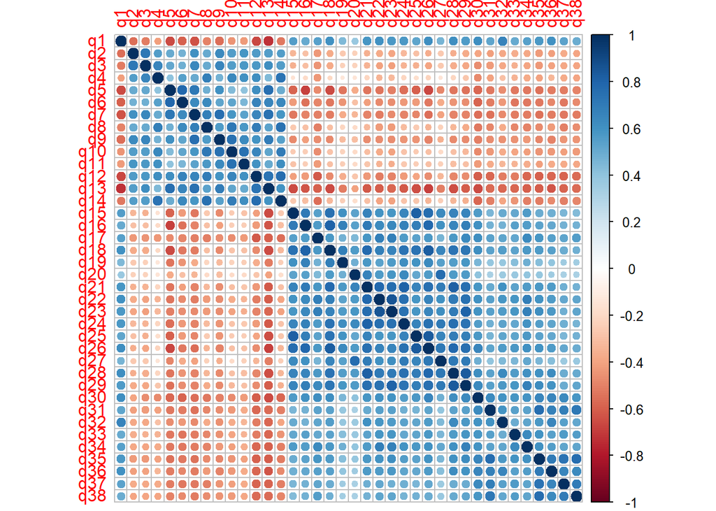

```r
nomiss = na.omit(nomiss)
correlation = cor(nomiss[, -1])
# symnum(correlation)
corrplot(correlation)
```

QUESTION: Do you appear to meet the assumption of additivity? Be sure to say more than yes or no, explain how you came to that conclusion.

### Assumptions Set Up

- Create a `random` variable using the `rchisq()` function.
- Create a `fake` regression using the data to predict your new random variable.
- From this regression, calculate the `standardized` residuals and the `fittedvalues` to use below for assumptions checks.

```r
random = rchisq(nrow(nomiss), 7)
fake = lm(random ~., data = nomiss[,-1])
standardized = rstudent(fake)
fitted = scale(fake$fitted.values)
```

### Normality

- Use the `plot()` function on your `standardized` residuals.

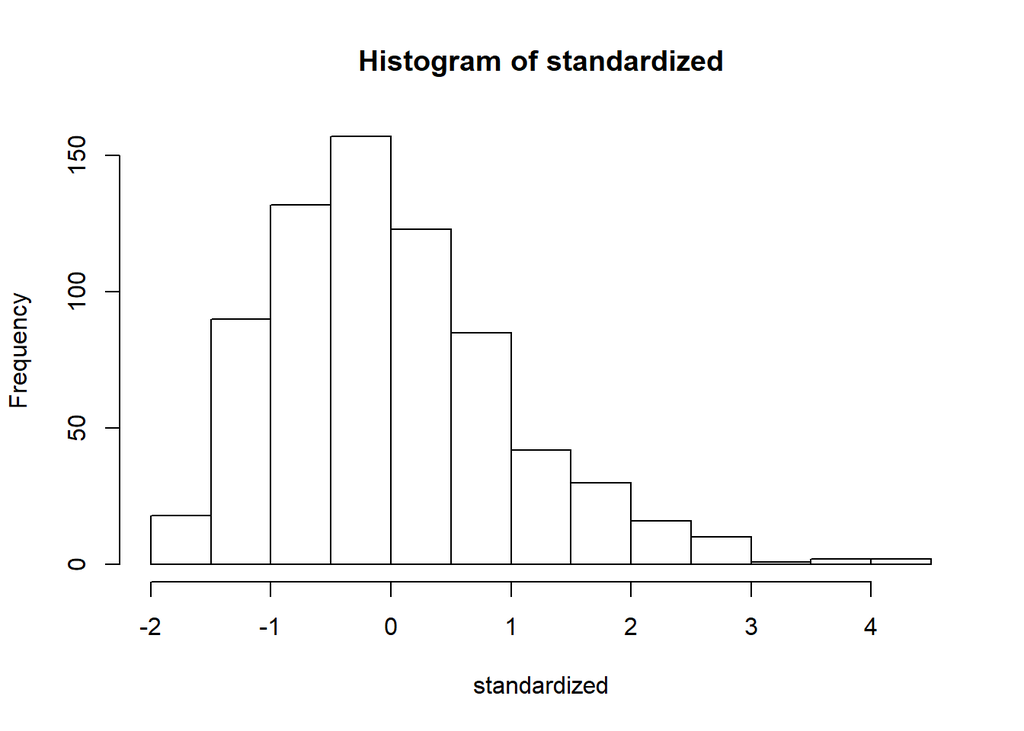

```r
hist(standardized)
```

QUESTION: Do you appear to meet the assumption of normality? Be sure to say more than yes or no, explain how you came to that conclusion.

ANSWER: Data is normal between the values of -2 and 2. Therefore, it can be concluded that the data is normal. Somewhat skewed but normal.

### Linearity

- Include the QQ plot for linearity using either `plot()` or `qqnorm()`.

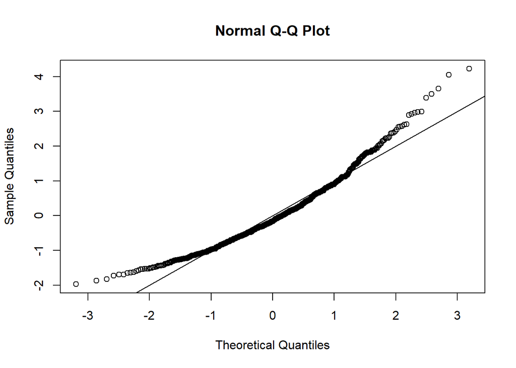

```r
qqnorm(standardized)
abline(0,1)
```

QUESTION: Do you appear to meet the assumption of linearity? Be sure to say more than yes or no, explain how you came to that conclusion. Yes. Most of the data is on the normal line. Some data points on the not close to the line. But overall, the assumption of Linearity is met.

### Homogeneity and Homoscedasticity

- Include a residual scatterplot of the data with `abline()` for vertical and horizontal at 0.

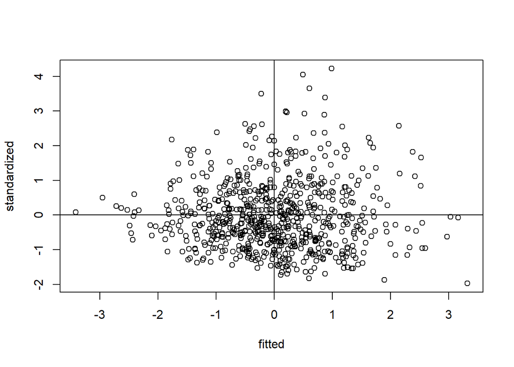

```r
plot(fitted, standardized)
abline(0,0)
abline(v = 0)
```

QUESTION: Do you appear to meet the assumption of homogeneity and homoscedasticity? Be sure to say more than yes or no, explain how you came to that conclusion.

## EFA

### Number of factors:

- Theory suggests two factors.
- Include the sum of the eigenvalues for both Kaiser criterions.
- Include the `fa.parallel` analysis to see the scree plot and parallel analysis.

```r
number_items <- fa.parallel(nomiss, fm="ml", fa="fa")
```

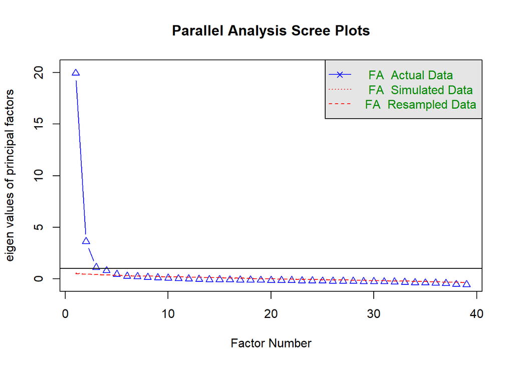

```
## Parallel analysis suggests that the number of factors =  5  and the number of components =  NA
```

```r
sum(number_items$fa.values > 1) # Old Kaiser
```

```
## [1] 3
```

```r
sum(number_items$fa.values > .7) # New Kaiser
```

```
## [1] 4
```

QUESTION: What do the different criterion’s suggest you should examine for the number of factors?

ANSWER: 3 or 4 factors.

### Simple structure:

- Calculate the factor analysis `fa` with two factors, maximum likelihood as the fitting estimation, and direct oblim as the rotation.

```r
EFA_fit <- fa(nomiss[, -1], nfactors = 2, rotate = "oblimin", fm = "ml")
EFA_fit
```

```
## Factor Analysis using method =  ml
## Call: fa(r = nomiss[, -1], nfactors = 2, rotate = "oblimin", fm = "ml")
## Standardized loadings (pattern matrix) based upon correlation matrix
##       ML1   ML2   h2   u2 com
## q1   0.46 -0.43 0.60 0.40 2.0
## q2  -0.07  0.66 0.49 0.51 1.0
## q3  -0.07  0.68 0.52 0.48 1.0
## q4   0.19  0.87 0.63 0.37 1.1
## q5  -0.48  0.41 0.60 0.40 2.0
## q6  -0.24  0.61 0.58 0.42 1.3
## q7  -0.27  0.63 0.64 0.36 1.3
## q8   0.06  0.85 0.68 0.32 1.0
## q9  -0.20  0.64 0.58 0.42 1.2
## q10  0.10  0.86 0.66 0.34 1.0
## q11  0.06  0.77 0.54 0.46 1.0
## q12 -0.14  0.78 0.74 0.26 1.1
## q13 -0.49  0.49 0.73 0.27 2.0
## q14  0.08  0.90 0.74 0.26 1.0
## q15  0.83  0.04 0.65 0.35 1.0
## q16  0.84  0.03 0.68 0.32 1.0
## q17  0.50 -0.36 0.56 0.44 1.8
## q18  0.88  0.02 0.77 0.23 1.0
## q19  0.73  0.06 0.50 0.50 1.0
## q20  0.75  0.14 0.47 0.53 1.1
## q21  0.91  0.06 0.77 0.23 1.0
## q22  0.75 -0.13 0.68 0.32 1.1
## q23  0.75 -0.13 0.67 0.33 1.1
## q24  0.88  0.05 0.73 0.27 1.0
## q25  0.85  0.06 0.68 0.32 1.0
## q26  0.90  0.01 0.80 0.20 1.0
## q27  0.85  0.14 0.62 0.38 1.1
## q28  0.87  0.01 0.76 0.24 1.0
## q29  0.85 -0.03 0.75 0.25 1.0
## q30  0.50 -0.41 0.62 0.38 1.9
## q31  0.40 -0.43 0.52 0.48 2.0
## q32  0.53 -0.25 0.49 0.51 1.4
## q33  0.50 -0.30 0.49 0.51 1.7
## q34  0.55 -0.30 0.56 0.44 1.5
## q35  0.48 -0.39 0.59 0.41 1.9
## q36  0.48 -0.35 0.54 0.46 1.8
```

[output cut: 21 more lines]

```
## The root mean square of the residuals (RMSR) is  0.05
## The df corrected root mean square of the residuals is  0.05
##
## The harmonic number of observations is  708 with the empirical chi square  2393.43  with prob <  1e-203
## The total number of observations was  708  with Likelihood Chi Square =  5824.71  with prob <  0
##
## Tucker Lewis Index of factoring reliability =  0.785
## RMSEA index =  0.108  and the 90 % confidence intervals are  0.106 0.111
## BIC =  1703.49
## Fit based upon off diagonal values = 0.99
## Measures of factor score adequacy
##                                                    ML1  ML2
## Correlation of (regression) scores with factors   0.99 0.98
## Multiple R square of scores with factors          0.98 0.96
## Minimum correlation of possible factor scores     0.95 0.92
```

- Remove any items that do not load on either factor or load on both factors. You may need to examine the `fa` output several times to come up with a final model.

```r
EFA_fit2 = fa(nomiss[, -c(1,2,6,14,18,31,32,34:39)], nfactors = 2, rotate = "oblimin", fm = "ml")
EFA_fit2
```

```
## Factor Analysis using method =  ml
## Call: fa(r = nomiss[, -c(1, 2, 6, 14, 18, 31, 32, 34:39)], nfactors = 2,
##     rotate = "oblimin", fm = "ml")
## Standardized loadings (pattern matrix) based upon correlation matrix
##       ML1   ML2   h2   u2 com
## q2  -0.09  0.67 0.51 0.49 1.0
## q3  -0.09  0.69 0.54 0.46 1.0
## q4   0.16  0.87 0.65 0.35 1.1
## q6  -0.26  0.58 0.55 0.45 1.4
## q7  -0.28  0.63 0.64 0.36 1.4
## q8   0.03  0.84 0.69 0.31 1.0
## q9  -0.22  0.66 0.62 0.38 1.2
## q10  0.08  0.87 0.71 0.29 1.0
## q11  0.04  0.78 0.58 0.42 1.0
## q12 -0.16  0.75 0.70 0.30 1.1
## q14  0.05  0.87 0.72 0.28 1.0
## q15  0.81  0.01 0.65 0.35 1.0
## q16  0.83  0.01 0.68 0.32 1.0
## q18  0.87 -0.01 0.77 0.23 1.0
## q19  0.72  0.03 0.50 0.50 1.0
## q20  0.74  0.10 0.48 0.52 1.0
## q21  0.89  0.02 0.79 0.21 1.0
## q22  0.74 -0.16 0.68 0.32 1.1
## q23  0.74 -0.15 0.68 0.32 1.1
## q24  0.87  0.02 0.74 0.26 1.0
## q25  0.84  0.04 0.67 0.33 1.0
## q26  0.89 -0.01 0.80 0.20 1.0
## q27  0.84  0.10 0.64 0.36 1.0
## q28  0.86 -0.02 0.76 0.24 1.0
## q29  0.84 -0.06 0.75 0.25 1.0
## q32  0.53 -0.24 0.46 0.54 1.4
##
##                         ML1  ML2
## SS loadings           10.30 6.66
## Proportion Var         0.40 0.26
## Cumulative Var         0.40 0.65
## Proportion Explained   0.61 0.39
## Cumulative Proportion  0.61 1.00
##
##  With factor correlations of
```

[output cut: 10 more lines]

```
## The root mean square of the residuals (RMSR) is  0.04
## The df corrected root mean square of the residuals is  0.05
##
## The harmonic number of observations is  708 with the empirical chi square  852.74  with prob <  1.2e-60
## The total number of observations was  708  with Likelihood Chi Square =  3163.9  with prob <  0
##
## Tucker Lewis Index of factoring reliability =  0.812
## RMSEA index =  0.122  and the 90 % confidence intervals are  0.118 0.126
## BIC =  1365.79
## Fit based upon off diagonal values = 0.99
## Measures of factor score adequacy
##                                                    ML1  ML2
## Correlation of (regression) scores with factors   0.99 0.97
## Multiple R square of scores with factors          0.97 0.95
## Minimum correlation of possible factor scores     0.94 0.90
```

QUESTION: What is the logic of excluding items that do not achieve simple structure?

ANSWER: Exclude values when over 0.3 and -0.3 or values both under 0.3 and -0.3